# Visualizing a DAPC analysis with ggplot2

Dr. Wilson Frantine-Silva

2022-06-22

# DAPC analysis with ggplot2

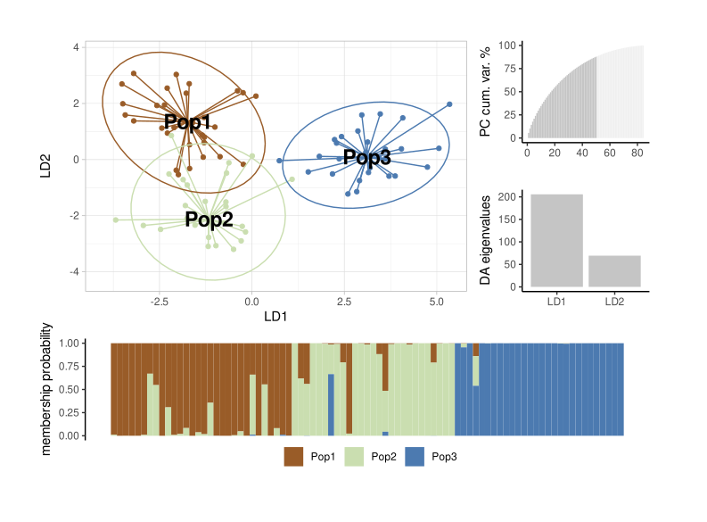

A DAPC plot built with ggplot2

This is a simple example of how to run a simple DAPC analysis with SSR or SNIP data.

For details about DAPC, see the `adegenet` package documentation and Joumbart et al., (2010).

DAPC analysis is very useful for the exploratory analysis of genetic data. It does not rely on Hardy-Weinberg equilibrium assumptions or other genetic models our data often breaks.

```r
library("devtools")
devtools::source_url("https://raw.githubusercontent.com/wilsonfrantine/ggDAPC/main/ggDAPC.R")
```

## Importing data

The `adegenet` package accepts several types of data, but the GENEPOP is one of most popular for sure.

> Make sure your file has .gen as extension.

After that, lets read it as an GENEPOP file with `read.genepop()` function, and create a summary of it.

> make sure to have `ncode` equal to the number of character used to code each alellel!

```r
data <- adegenet::read.genepop(file, ncode = 3)
```

```r
data %>% summary # or summary(data)
```

```
##
## // Number of individuals: 85
## // Group sizes: 30 27 28
## // Number of alleles per locus: 40 46 37 22 24 26 37 18
## // Number of alleles per group: 153 157 156
## // Percentage of missing data: 3.97 %
## // Observed heterozygosity: 0.89 0.83 0.89 0.78 0.34 0.86 0.9 0.91
## // Expected heterozygosity: 0.96 0.96 0.95 0.9 0.9 0.94 0.95 0.85
```

# Runing a simple DAPC

The most straightforward way to run a DAPC is by considering the implicit data strata (pop grouping as provided in the GENEPOP file).

The analysis will then provides Discriminant Functions, giving the populations provided, to maximize the differentiation between the groups provided by the user.

> Note! In this analysis, we’ll directly select Principal Components and Discriminant functions through the parameters `perc.pca` (% of cummulative var we wanna retain), `pca.select` (method to use % or n of PCs) and `n.da` (number of discriminant functions to retain). To see more, run `?dapc`.

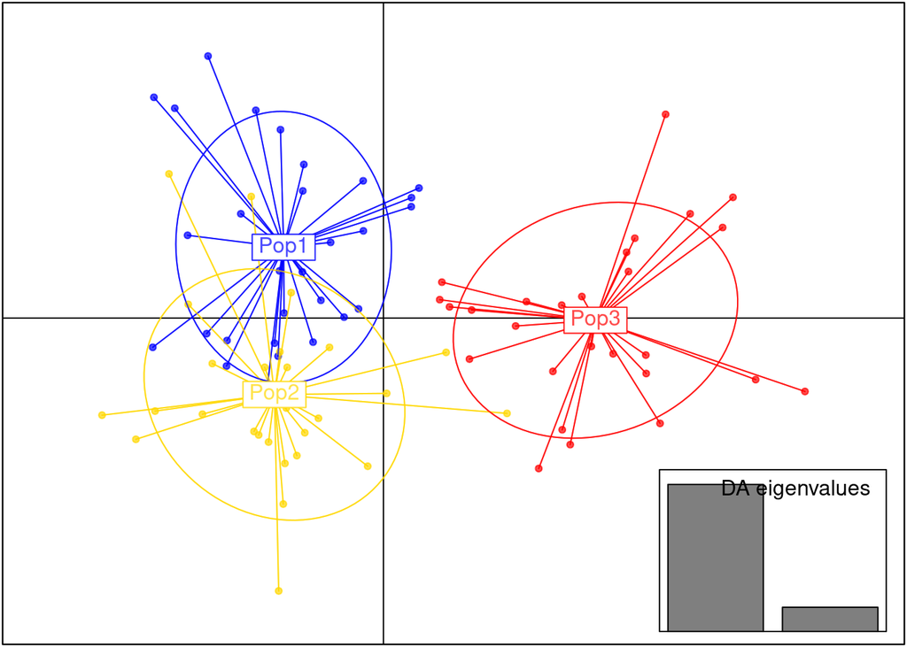

```r
PopDapc <- dapc(data, perc.pca = 70, pca.select = "percVar", n.da = 2)
scatter(PopDapc)
```

We can also run a `compoplot` (assignment barplot) for this analysis with the following lines:

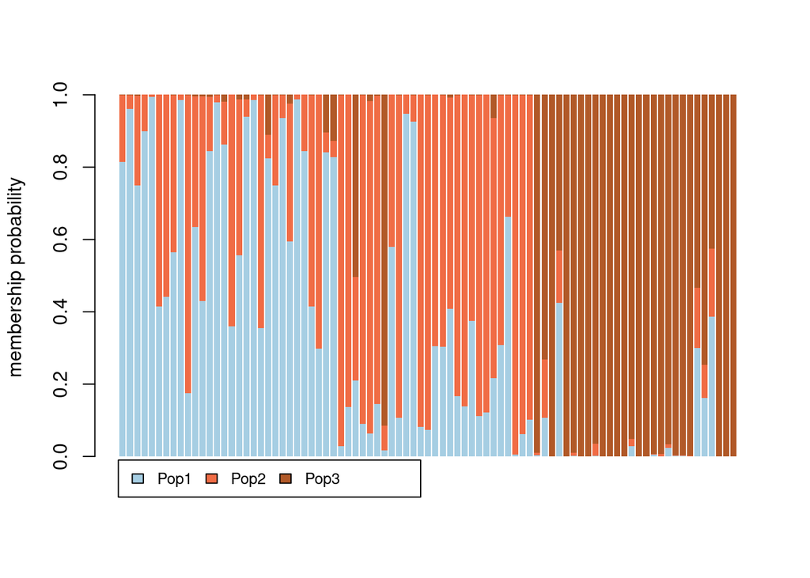

```r
compoplot(PopDapc) ## data %>% compoplot also works
```

## Plotting with ggplot2

There is nothing wrong with the original plots. They are great, but we can create more flexible plots with ggplot2.

Let’s say you don’t like the colors or the shape of either plot above, or that you would like to create a composition. Both tasks are few lines way with ggplot2

Once we have sourced the `ggDAPC.R` file, it is simple like the lines bellow

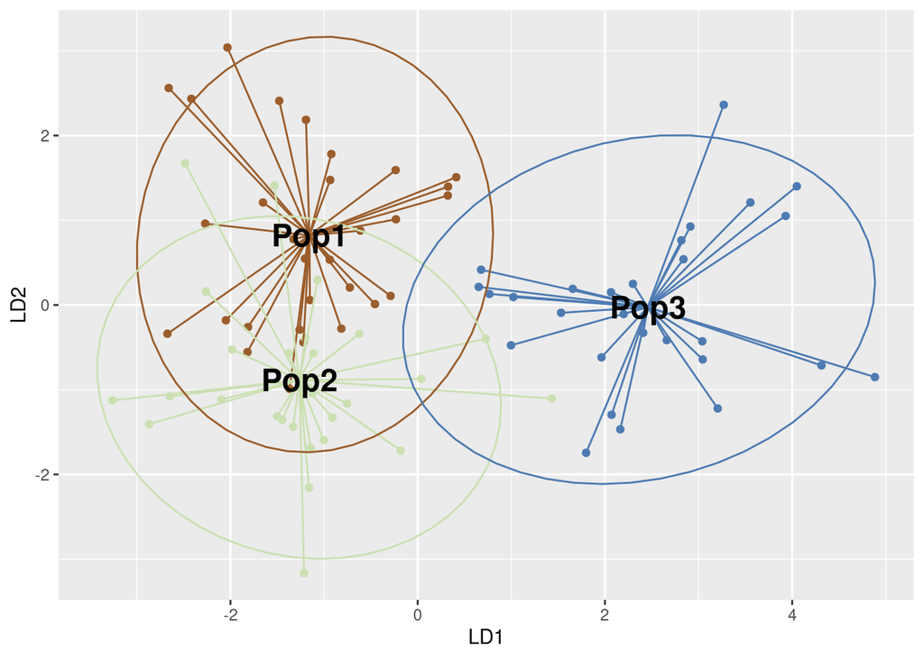

```r
ggPopDapc <- ggDapc(PopDapc)
ggPopDapc
```

Same for the `compoplot`:

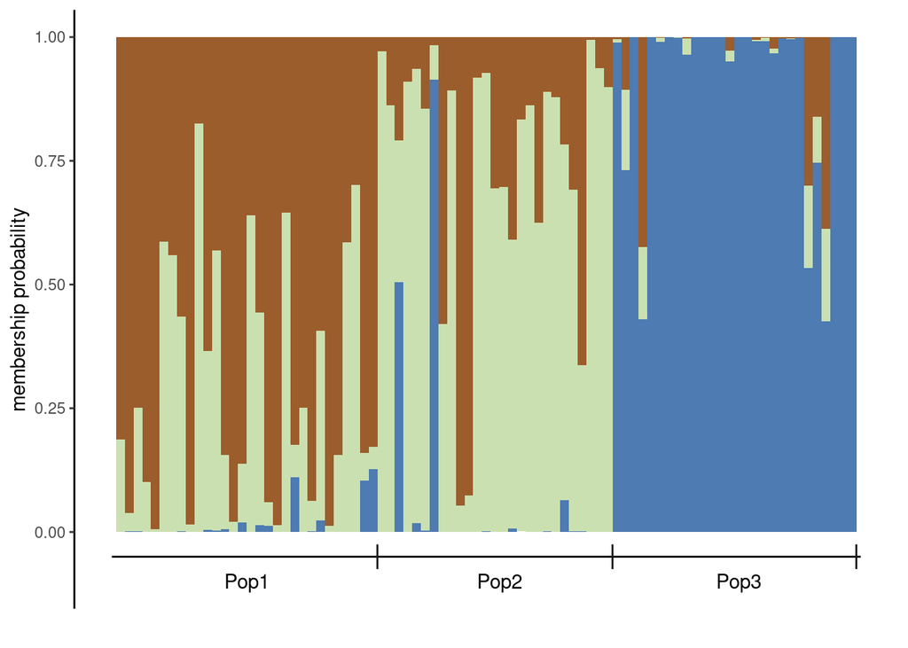

```r
popCompoplot <- ggCompoplot(PopDapc)
popCompoplot
```

Finally we can create any plot combination by mixing plots or changing their properties with ggplot2 syntax.

In the lines below we will create an layout to shape the plot area and then, we will create these plots, by calling their respective function:

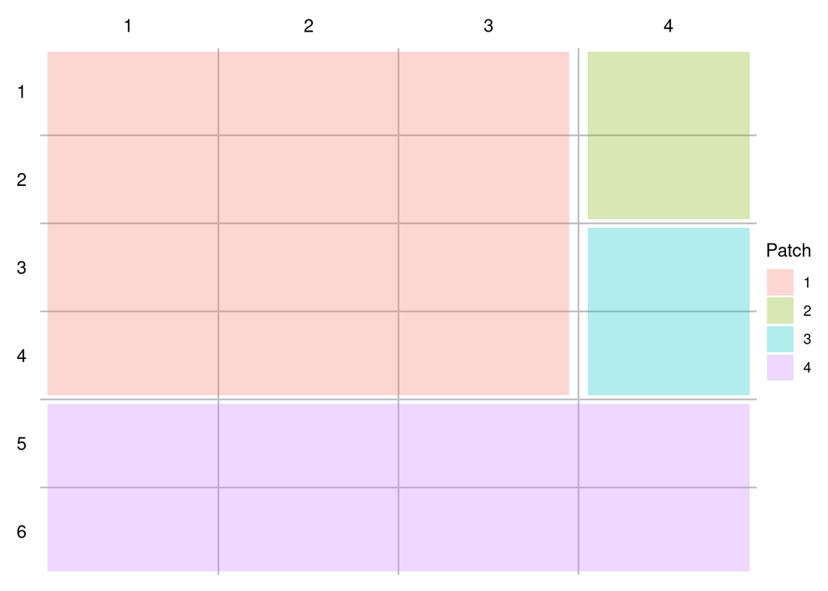

```r
layout <- c(
  patchwork::area(t = 1, l = 1, b = 4, r = 3),
  patchwork::area(t = 1, l = 4, b = 2, r = 4),
  patchwork::area(t = 3, l = 4, b = 4, r = 4),
  patchwork::area(t = 5, l = 1, b = 6, r = 4)
)
plot(layout)
```

The layout is simple to understand. Think about it as a table and the numbers in t, l, b, r indicate the cell where the top, left, bottom, and right will be the respective plot limits.

now, to the actual plot…

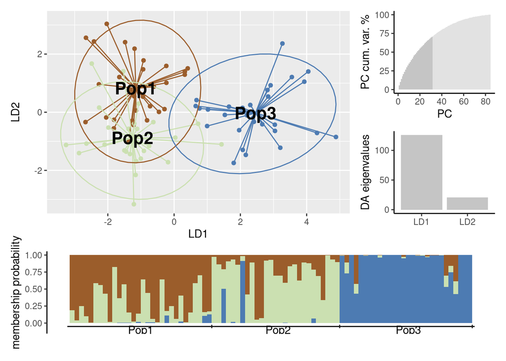

```r
ggDapc(PopDapc) + ggPCvar(PopDapc) +
ggDAplot(PopDapc) + ggCompoplot(PopDapc) +
patchwork::plot_layout(design = layout)
```

## References

- Jombart, T., Devillard, S., & Balloux, F. (2010). Discriminant analysis of principal components: a new method for the analysis of genetically structured populations. BMC genetics, 11(1), 1-15.